# Forecast about Unemployment, Inflation and GDP for Netherland

Misra Sonam

3/22/2020

## Install libraries

```r
library(tidyverse)
library(readxl)
library(corrgram)
library(tseries)
library(urca)
library(forecast)
library(trend)
library(zoo)
library(reshape)
```

## Read Data

```r
Unemployment<-read_excel("/Users/sonam/Desktop/Regression_data/MacroData.xlsx",sheet="Sheet2")
Inflation<-read_excel("/Users/sonam/Desktop/Regression_data/MacroData.xlsx",sheet="Sheet3")
GDP<-read_excel("/Users/sonam/Desktop/Regression_data/MacroData.xlsx",sheet="Sheet7")
```

## Data Preparation

```r
## Select variables from the larger dataset

Year<-Unemployment[1,c('Column6','Column7','Column8','Column9','Column10','Column11','Column12','Column13','Column14','Column15','Column16','Column17','Column18','Column19','Column20','Column21','Column22','Column23','Column24','Column25','Column26','Column27','Column28','Column29','Column30','Column31','Column32','Column33','Column34','Column35','Column36','Column37','Column38','Column39','Column40','Column41','Column42','Column43','Column44','Column45','Column46','Column47','Column48','Column49','Column50','Column51','Column52','Column53','Column54','Column55','Column56','Column57','Column58','Column59','Column60','Column61','Column62','Column63','Column64')]


NetherlandUn<-Unemployment[427,c('Column6','Column7','Column8','Column9','Column10','Column11','Column12','Column13','Column14','Column15','Column16','Column17','Column18','Column19','Column20','Column21','Column22','Column23','Column24','Column25','Column26','Column27','Column28','Column29','Column30','Column31','Column32','Column33','Column34','Column35','Column36','Column37','Column38','Column39','Column40','Column41','Column42','Column43','Column44','Column45','Column46','Column47','Column48','Column49','Column50','Column51','Column52','Column53','Column54','Column55','Column56','Column57','Column58','Column59','Column60','Column61','Column62','Column63','Column64')]


NetherlandInf<-Inflation[1092,c('Column6','Column7','Column8','Column9','Column10','Column11','Column12','Column13','Column14','Column15','Column16','Column17','Column18','Column19','Column20','Column21','Column22','Column23','Column24','Column25','Column26','Column27','Column28','Column29','Column30','Column31','Column32','Column33','Column34','Column35','Column36','Column37','Column38','Column39','Column40','Column41','Column42','Column43','Column44','Column45','Column46','Column47','Column48','Column49','Column50','Column51','Column52','Column53','Column54','Column55','Column56','Column57','Column58','Column59','Column60','Column61','Column62','Column63','Column64')]


NetherlandGDP<-GDP[552,c('Column6','Column7','Column8','Column9','Column10','Column11','Column12','Column13','Column14','Column15','Column16','Column17','Column18','Column19','Column20','Column21','Column22','Column23','Column24','Column25','Column26','Column27','Column28','Column29','Column30','Column31','Column32','Column33','Column34','Column35','Column36','Column37','Column38','Column39','Column40','Column41','Column42','Column43','Column44','Column45','Column46','Column47', 'Column48','Column49','Column50','Column51','Column52','Column53','Column54','Column55','Column56','Column57','Column58','Column59','Column60','Column61','Column62','Column63','Column64')]
```

```r
## Select variables from the larger dataset

t_NetherlandGDP<-t(NetherlandGDP)

t_NetherlandGDP<-as.numeric(t_NetherlandGDP)



t_NetherlandInf<-t(NetherlandInf)
t_NetherlandInf<-as.numeric(t_NetherlandInf)



t_NetherlandUnem<-t(NetherlandUn)
t_NetherlandUnem<-as.numeric(t_NetherlandUnem)


t_Year<-t(Year)
t_Year<-as.numeric(t_Year)

t_Year<-as.numeric(t_Year)
t_NetherlandUnem<-as.numeric(t_NetherlandUnem)
t_NetherlandGDP<-as.numeric(t_NetherlandGDP)
t_NetherlandInf[is.na(t_NetherlandInf)] <-0
t_NetherlandInf<-as.numeric(t_NetherlandInf)
```

```r
# its still a vector
TimeSeriesNetherland<-cbind(t_Year, t_NetherlandGDP, t_NetherlandInf, t_NetherlandUnem)


# inorder to work with timeseries convert to dataframe
TimeSeriesNetherland<-as.data.frame(TimeSeriesNetherland)


TimeSeriesNetherland <- rename(TimeSeriesNetherland, c(t_Year="Years"))

TimeSeriesNetherland <- rename(TimeSeriesNetherland, c(t_NetherlandGDP="GrossDP"))

TimeSeriesNetherland <- rename(TimeSeriesNetherland, c(t_NetherlandInf="Inflation"))

TimeSeriesNetherland <- rename(TimeSeriesNetherland, c(t_NetherlandUnem="Unemploy"))
```

```r
#tell R this is time series data

tsUR<-zoo(TimeSeriesNetherland$Unemploy, order.by = TimeSeriesNetherland$Years)

tsIF<-zoo(TimeSeriesNetherland$Inflation, order.by = TimeSeriesNetherland$Years)

tsGDP<-zoo(TimeSeriesNetherland$GrossDP, order.by = TimeSeriesNetherland$Years)
```

## create plots of the timeseries

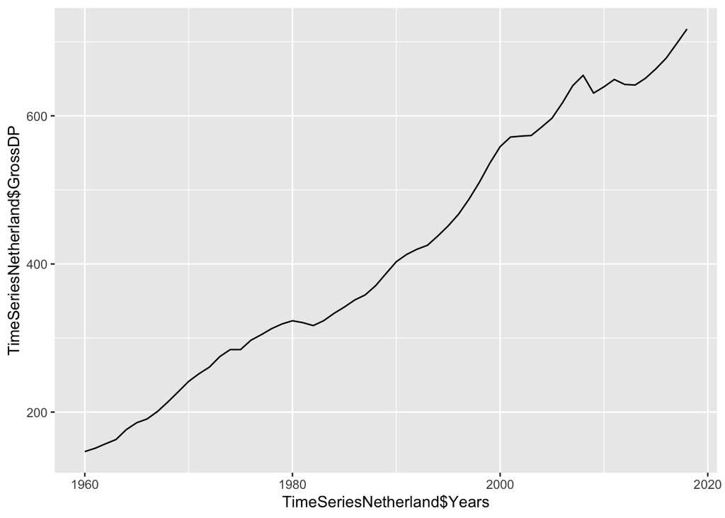

```r
ggplot(data = TimeSeriesNetherland, aes(x = TimeSeriesNetherland$Years, y = TimeSeriesNetherland$GrossDP)) + geom_line()
```

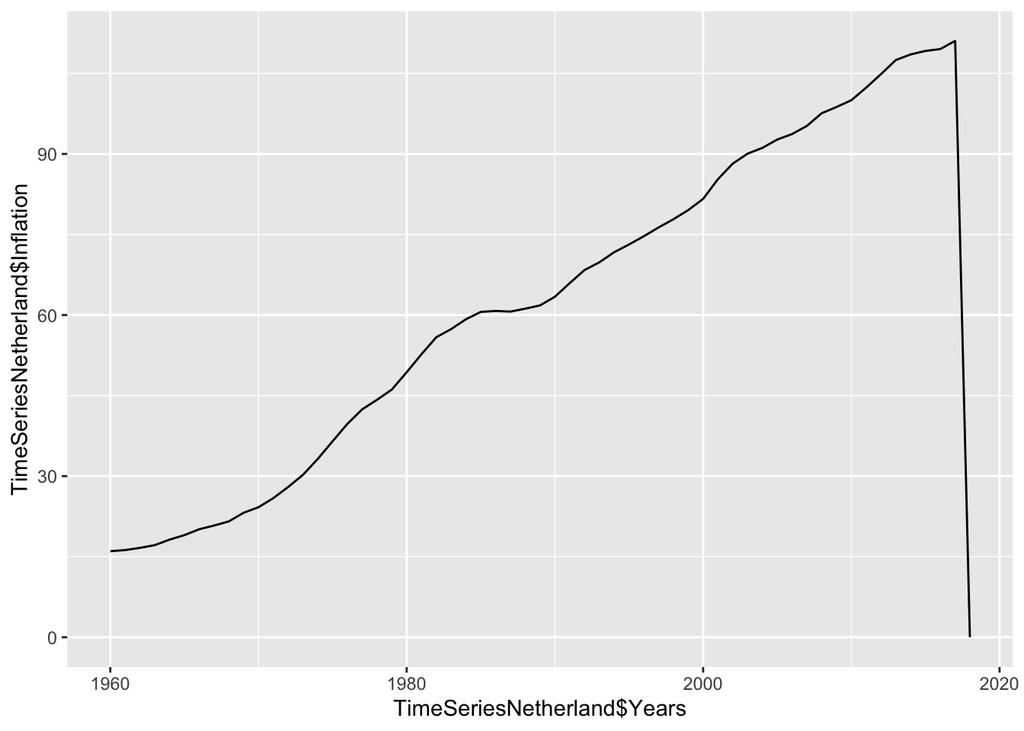

```r
ggplot(data = TimeSeriesNetherland, aes(x = TimeSeriesNetherland$Years, y = TimeSeriesNetherland$Inflation))+ geom_line()
```

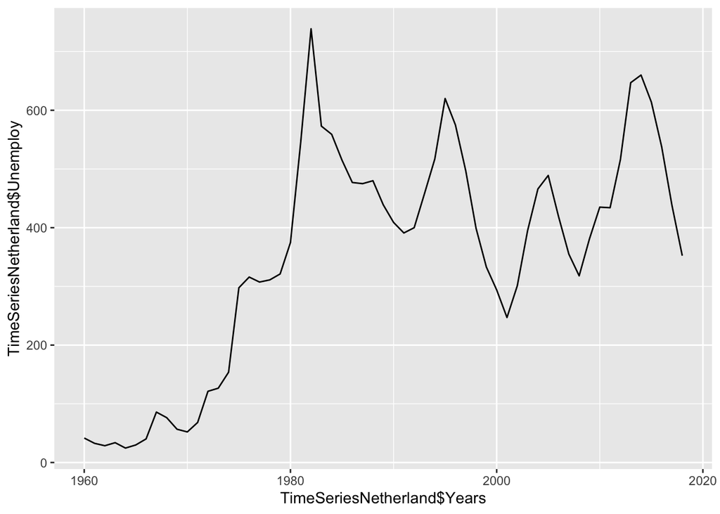

```r
ggplot(data = TimeSeriesNetherland, aes(x = TimeSeriesNetherland$Years, y = TimeSeriesNetherland$Unemploy))+ geom_line()
```

## ADF Test

- Time series work if underlying data is stationary.
- Timeseries is said to be stationary if it has constant mean and variance and covariance is independent of time. To test the same, ADF test is performed.

```r
adf.test(tsGDP)
```

```
##
##  Augmented Dickey-Fuller Test
##
## data:  tsGDP
## Dickey-Fuller = -2.1728, Lag order = 3, p-value = 0.5049
## alternative hypothesis: stationary
```

```r
adf.test(tsIF)
```

```
##
##  Augmented Dickey-Fuller Test
##
## data:  tsIF
## Dickey-Fuller = 0.33684, Lag order = 3, p-value = 0.99
## alternative hypothesis: stationary
```

```r
adf.test(tsUR)
```

```
##
##  Augmented Dickey-Fuller Test
##
## data:  tsUR
## Dickey-Fuller = -2.0556, Lag order = 3, p-value = 0.5523
## alternative hypothesis: stationary
```

- p-value > 0.05 for GPD, Inflation and Unemployment. Here, the we failed to reject null which means all three are non-stationary.
- To test for trend stationarity, KPSS test is performed.

## KPSS Test

```r
kpss.test(TimeSeriesNetherland$GrossDP, null = "Trend")
```

```
##
##  KPSS Test for Trend Stationarity
##
## data:  TimeSeriesNetherland$GrossDP
## KPSS Trend = 0.19838, Truncation lag parameter = 3, p-value =
## 0.01661
```

```r
kpss.test(TimeSeriesNetherland$Inflation, null = "Trend")
```

```
##
##  KPSS Test for Trend Stationarity
##
## data:  TimeSeriesNetherland$Inflation
## KPSS Trend = 0.14098, Truncation lag parameter = 3, p-value =
## 0.0593
```

```r
kpss.test(TimeSeriesNetherland$Unemploy, null = "Trend")
```

```
##
##  KPSS Test for Trend Stationarity
##
## data:  TimeSeriesNetherland$Unemploy
## KPSS Trend = 0.23954, Truncation lag parameter = 3, p-value = 0.01
```

- p-value < 0.05 for GDP and Unemployment. Here, we reject the null hypothesis, which means data is nonstationary.
- P-value > 0.05 for inflation. Here, we fail to reject the null hypothesis, which means data for inflation is trend stationary.

## Correlograms of Unemployment, Inflation and GDP data

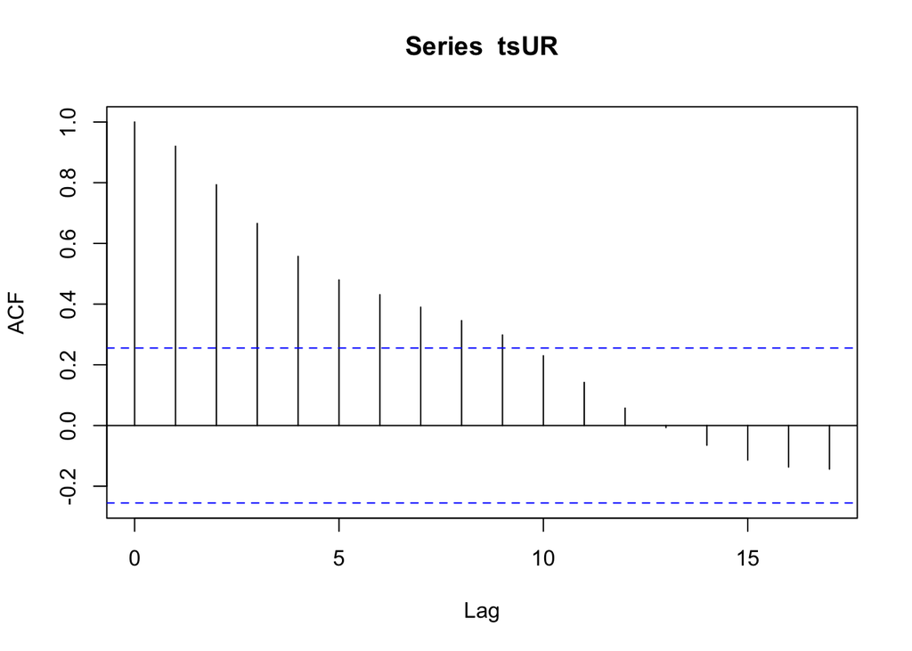

```r
acf(tsUR)
```

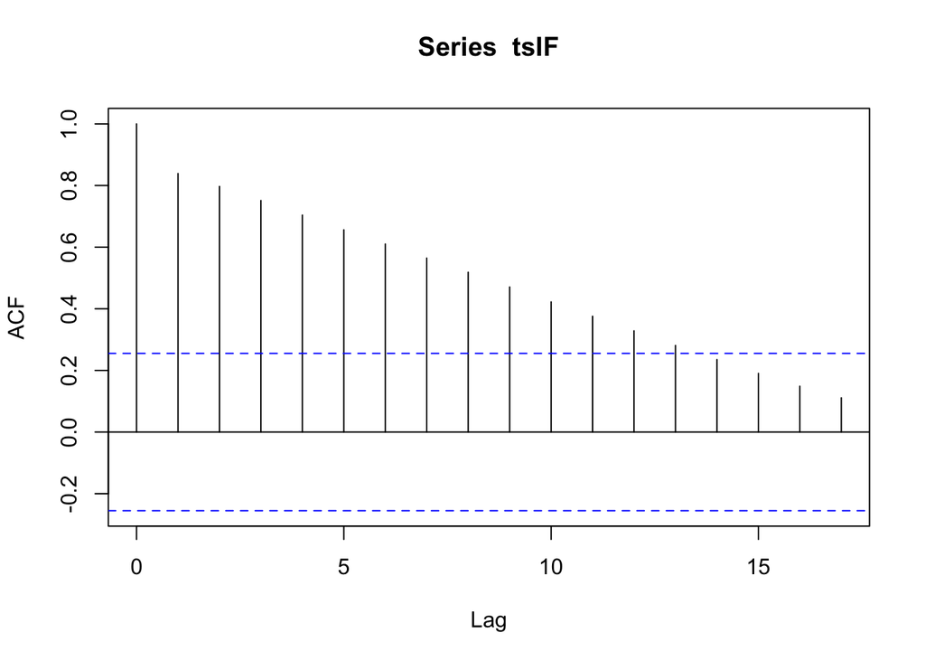

```r
acf(tsIF)
```

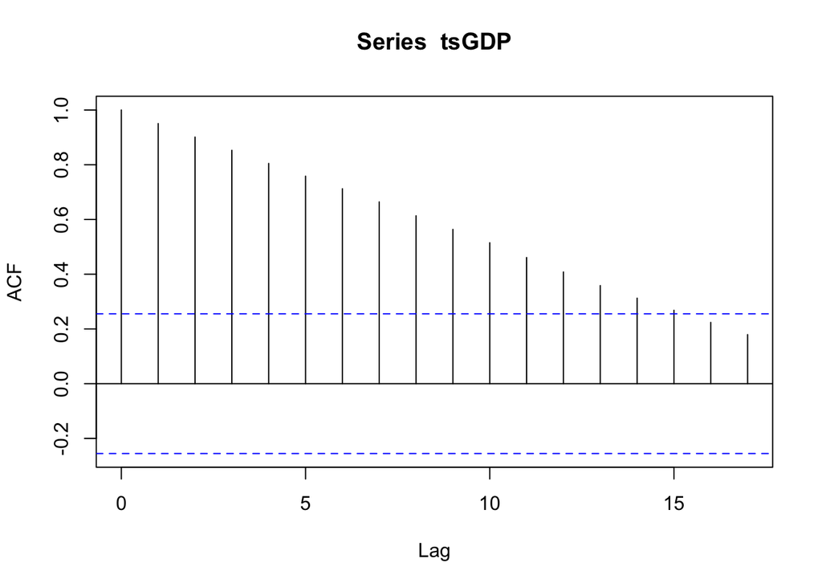

```r
acf(tsGDP)
```

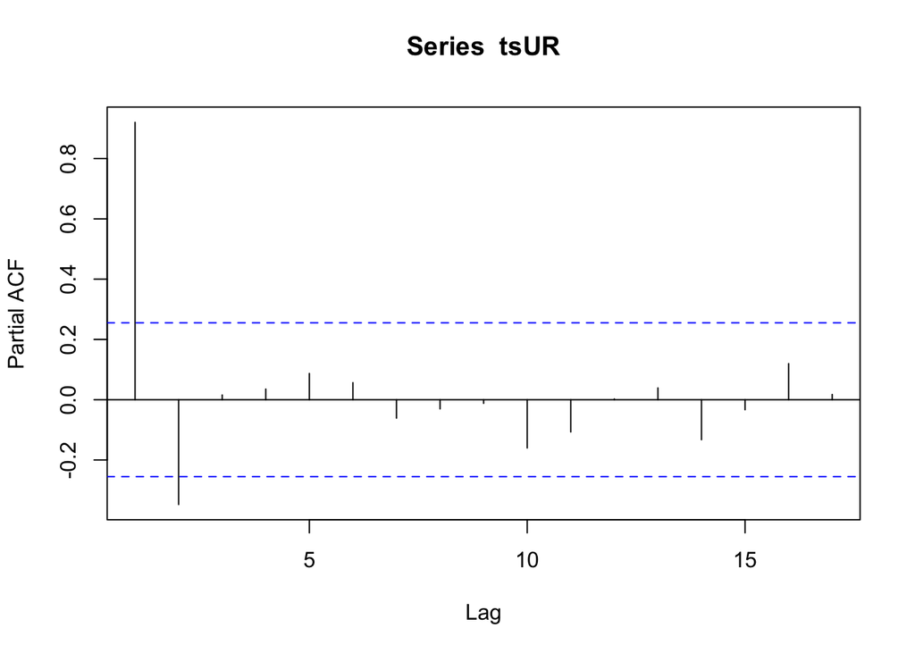

```r
pacf(tsUR)
```

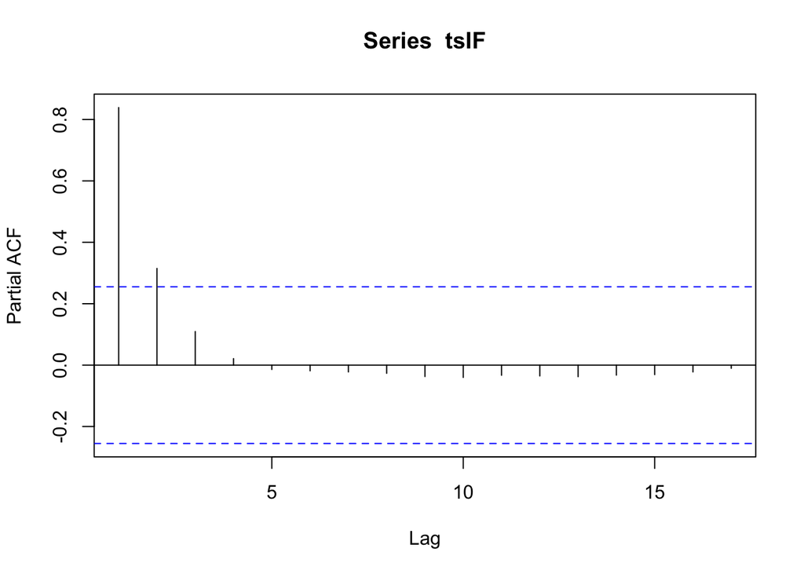

```r
pacf(tsIF)
```

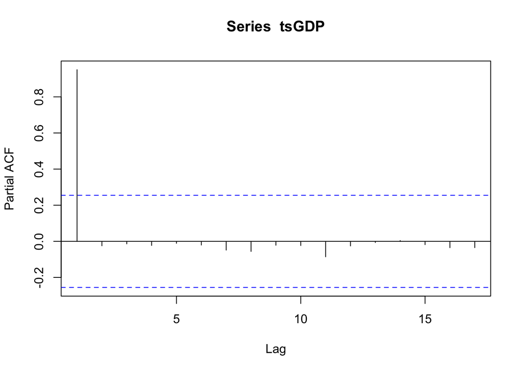

```r
pacf(tsGDP)
```

- After analyzing the above ACF and PACF plots, data is transformed by differencing to achieve stationarity as prediction can be performed on stationary data. Below is KPSS test which proves data for GDP and Unemployment has become trend stationary.

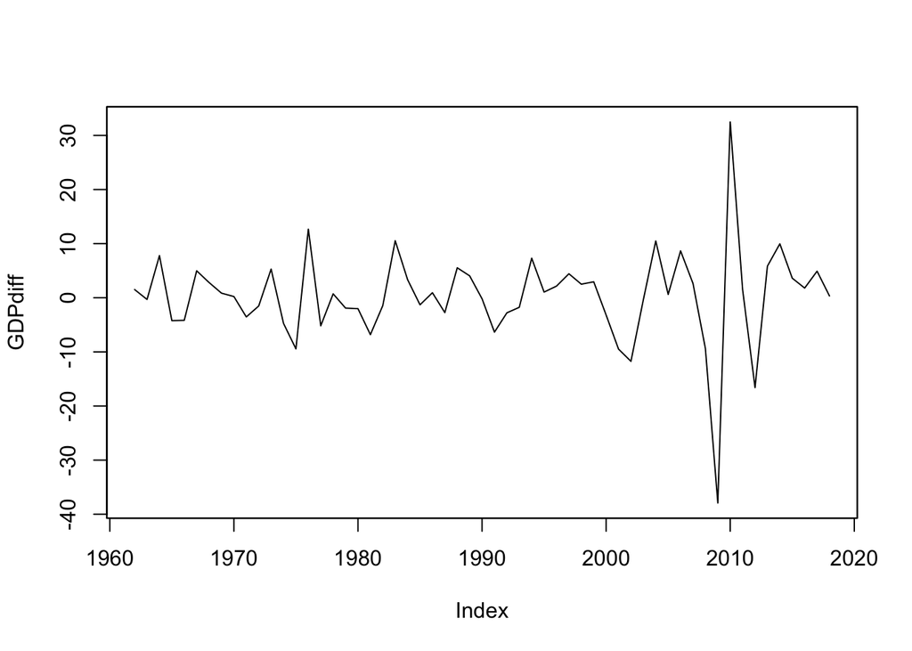

```r
YearDiff=diff(TimeSeriesNetherland$Years,differences=4)
URdiff=diff(tsUR, differences=2 )
GDPdiff=diff(tsGDP)
GDPdiff=diff(tsGDP,differences=2)

plot(GDPdiff)
```

## ACF / PACF Plots After Differencing

```r
kpss.test(URdiff, null = "Trend")
```

```
##
##  KPSS Test for Trend Stationarity
##
## data:  URdiff
## KPSS Trend = 0.031425, Truncation lag parameter = 3, p-value = 0.1
```

```r
kpss.test(GDPdiff, null = "Trend")
```

```
##
##  KPSS Test for Trend Stationarity
##
## data:  GDPdiff
## KPSS Trend = 0.041703, Truncation lag parameter = 3, p-value = 0.1
```

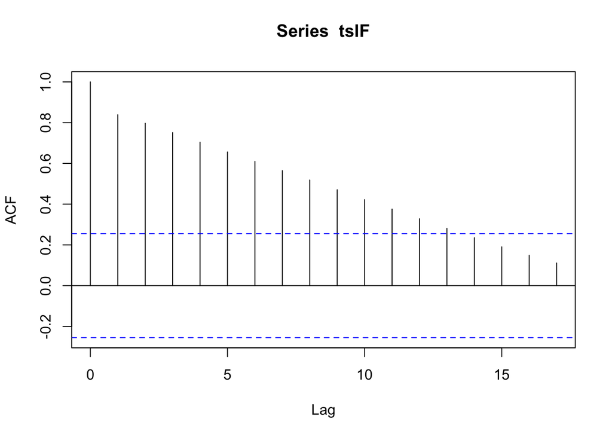

```r
acf(tsIF)
```

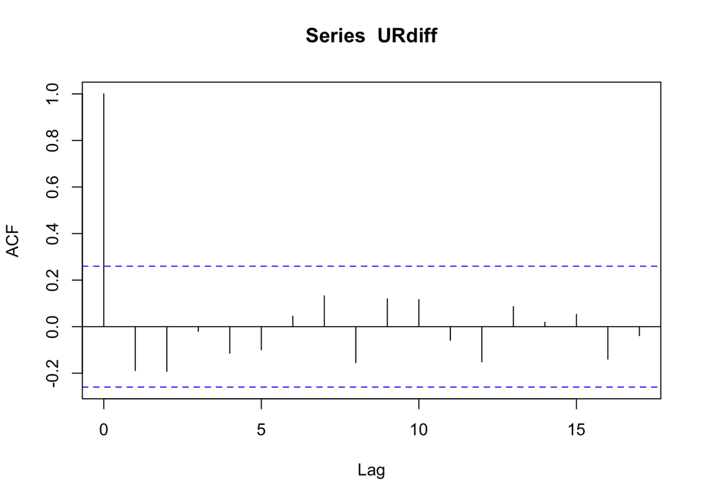

```r
acf(URdiff)
```

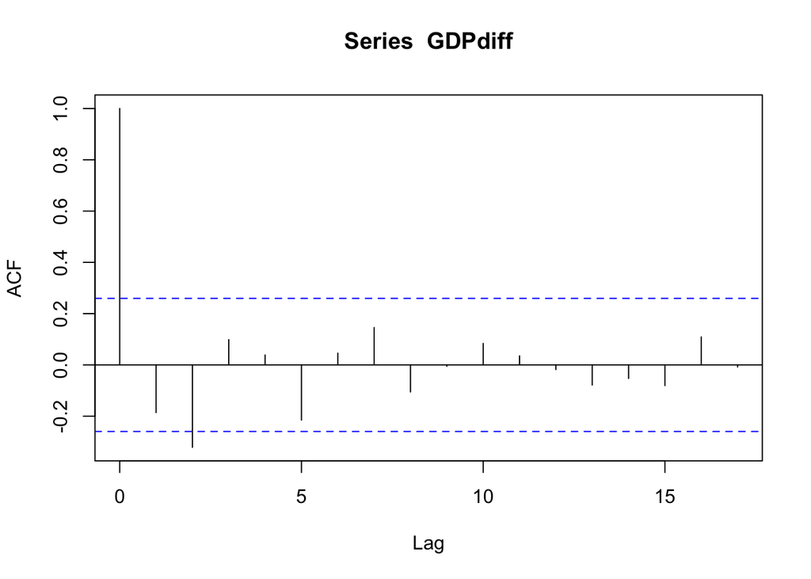

```r
acf(GDPdiff)
```

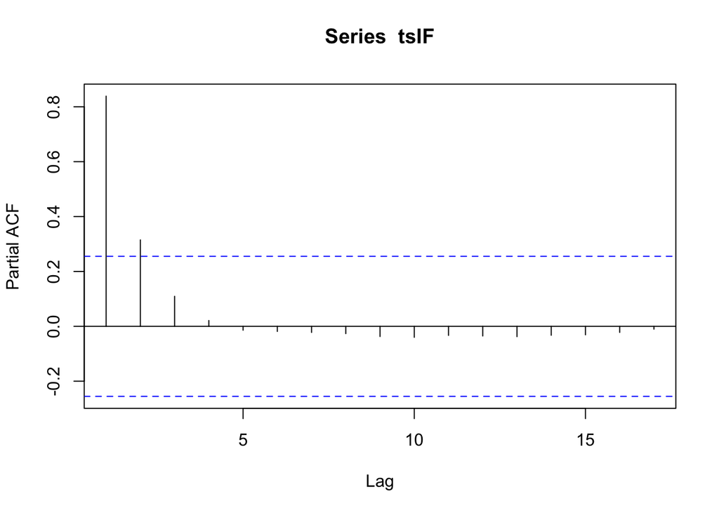

```r
pacf(tsIF)
```

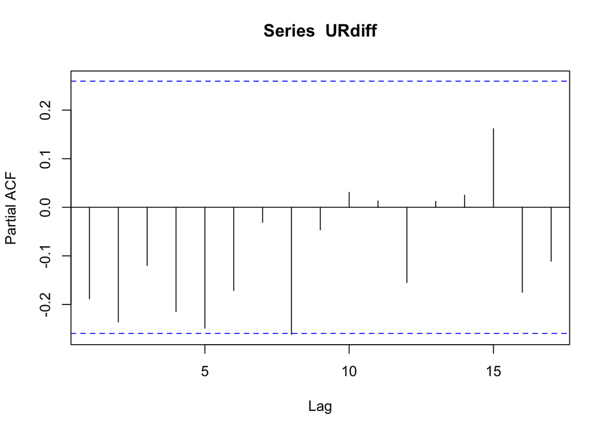

```r
pacf(URdiff)
```

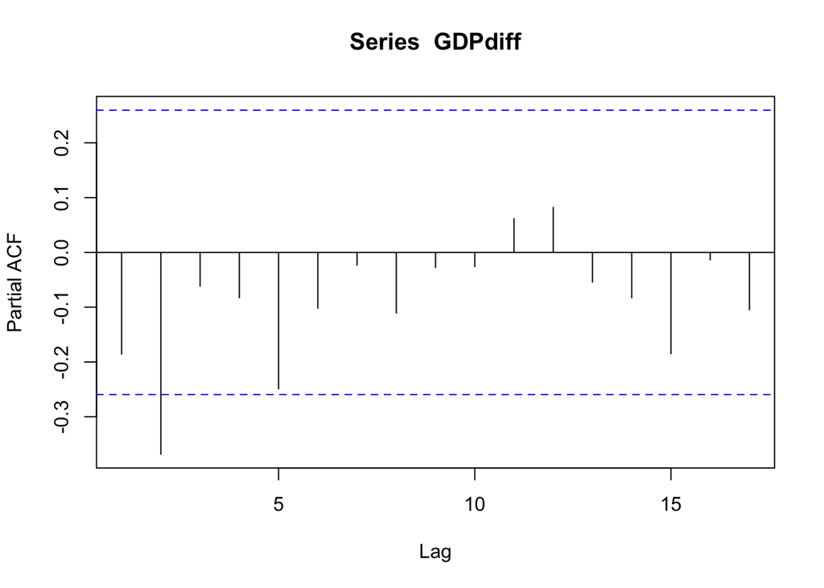

```r
pacf(GDPdiff)
```

## Model for Inflation, Unemployment and GDP:

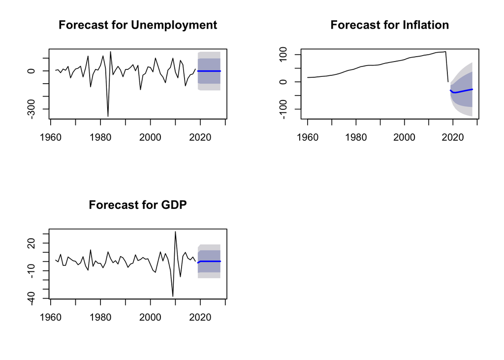

```r
UmData <- Arima(URdiff, order = c(0, 1, 2),
                include.mean = FALSE, include.drift = FALSE, include.constant =FALSE,
                method = "ML")
InfData <- Arima(tsIF, order = c(2, 0, 0),
                 include.mean = FALSE, include.drift = FALSE, include.constant =FALSE,
                 method = "ML")
GDPData <- Arima(GDPdiff, order = c(0, 1, 2),
                 include.mean = FALSE, include.drift = FALSE, include.constant =FALSE,
                 method = "ML")

par(mfrow=c(2,2))

plot(forecast(UmData,h=10), main="Forecast for Unemployment")
plot(forecast(InfData,h=10), main="Forecast for Inflation")
plot(forecast(GDPData,h=10), main="Forecast for GDP")
```